# Módulo 2

Modelos de Regresión

Eloy Alvarado Narváez

eloy.alvarado@usm.cl

Universidad Técnica Federico Santa María

Esteban Salgado Valenzuela

Universidad Técnica Federico Santa María

13 de diciembre de 2024

## Regresión Lineal

- Regresión lineal es un método simple para el aprendizaje supervisado.
- Asume que la dependencia de $Y$ en $X_1,\ldots,X_p$ es lineal
  $$Y = \beta_0 + \beta_1X_1 + \cdots + \beta_pX_p$$
- Las funciones de regresión reales nunca son lineales.
- Aunque simple, es útil teórica y prácticamente.

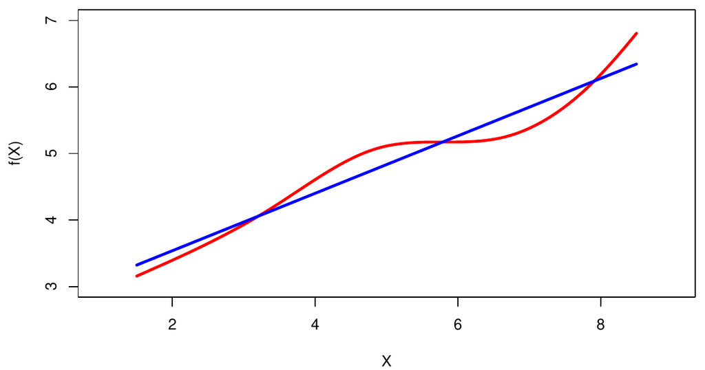

# Regresión lineal simple

## Regresión lineal simple

- Recordando los datos de publicidad:
  - ¿Hay relación entre el presupuesto de publicidad y las ventas?
  - ¿Qué tan fuerte es la relación?
  - ¿Qué medio contribuye a las ventas?
  - ¿Qué tan precisamente se pueden predecir ventas futuas?
  - ¿Es lineal la relación o hay *interacciones*?

## Regresión lineal simple

### Definición

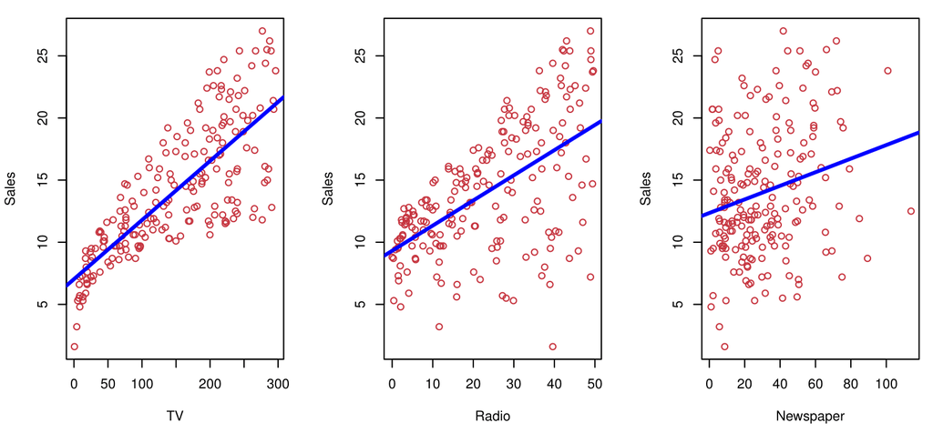

## Regresión lineal simple

- Se considera el modelo

$$Y = \beta_0 + \beta_1X + \varepsilon,$$
cuyos coeficientes (variables) son $\beta_0$ y $\beta_1$.

Se estiman los coeficientes para predecir las ventas

$$y = \hat{\beta_0} + \hat{\beta_1}x$$

## Regresión lineal simple

### Solución

- Se define el residuo de suma cuadrática como

$$RSS = e_1^2+\cdots+e_n^2,$$
con $e_i = y_i-\hat{y_i} = y_i-\hat{\beta_0}-\hat{\beta_1}x_i$

- Se puede resolver analíticamente:

$$\hat{\beta_1} = \dfrac{\sum\limits_{i=1}^n(x_i-\bar{x})(y_i-\bar{y})}{\sum\limits_{i=1}^n(x_i-\bar{x})^2} \text{ y } \hat{\beta_0} = \bar{y} - \hat{\beta_1}\bar{x}.$$

## Regresión lineal simple

### Intervalo de confianza

- El error estándar de los estimadores es:

$$SE(\hat{\beta_1})^2 = \dfrac{\sigma^2}{\sum\limits_{i=1}^n(x_i-\bar{x})} \text{ y } SE(\hat{\beta_0})^2 = \sigma^2\left[\frac{1}{n} + \dfrac{\bar{x}^2}{\sum\limits_{i=1}^n(x_i-\bar{x})^2}\right]$$

- Intervalo de confianza con $95\%$ de confianza

$$\hat{\beta_i} \pm 2\cdot SE(\hat{\beta_i}).$$

## Regresión lineal simple

### Test de Hipótesis

- El test de hipótesis más común, involucra testear la hipótesis nula de:
  - $H_0:$ No hay relación entre $X$ e $Y$ ($\beta_1 = 0$).
  - $H_A:$ Hay relación entre $X$ e $Y$ ($\beta_1 \neq 0$).
- Para testearlo se usa el estadístico $t$

$$t = \dfrac{\hat{\beta_1}-0}{SE(\hat{\beta_1})} \sim t-\text{Student}(n-2)$$

- p-value es la probabilidad de observar un valor $\ge|t|$.

## Regresión lineal simple

### Ejemplo publicidad

|  | Coeficiente | SE | t-stadistic | p-value |
| --- | --- | --- | --- | --- |
| Intercepto | 7.0325 | 0.4578 | 15.36 | < 0.0001 |
| TV | 0.0475 | 0.0027 | 17.67 | < 0.0001 |

- Para tener un p-value bajo $0.05$ se requiere un t-stadistic de 2.
- La probabilidad de ver este resultado bajo la hipótesis nula es $<0.0001$.
- Se rechaza la hipótesis nula, i.e. $\beta_1\neq0$.

## Regresión lineal simple

### Precisión del modelo

- Error estándar residual:

$$RSE = \sqrt{\frac{1}{n-2}RSS} = \sqrt{\frac{1}{n-2}\sum\limits_{i=1}^n(y_i-\hat{y_i})^2}$$

- $R^2$ fracción de la varianza explicada es:

$$R^2 = 1 - \dfrac{RSS}{TSS},$$

con $TSS = \sum\limits_{i=1}^n(y_i-\bar{y})^2$.

## Regresión lineal simple

### Precisión del modelo: Ejemplo

| Cantidad | Valor |
| --- | --- |
| RSE | 3.26 |
| $R^2$ | 0.612 |

- Usando el presupuesto para `TV` la varianza en ventas se reduce en un $61\%$.

# Regresión lineal múltiple

## Regresión lineal múltiple

### Definición

- El modelo es:

$$Y = \beta_0 + \beta_1X_1 + \cdots \beta_pX_p + \varepsilon.$$

- $\beta_j$ se interpreta como el cambio promedio en $Y$ por unidad de aumento en $X_j$, manteniendo los demás predictores fijos.
- En el ejemplo de publicidad:

$$sales = β_0 + β_1\cdot TV + β_2\cdot radio + β_3 \cdot newspaper + \varepsilon.$$

## Regresión lineal múltiple

### Ejemplo presupuesto

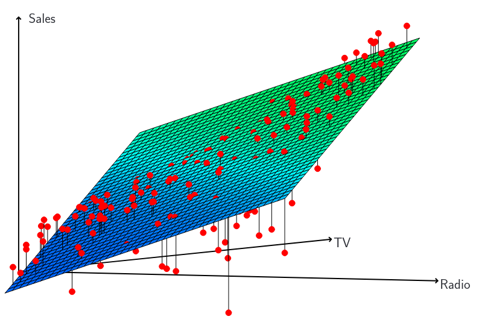

## Regresión lineal múltiple

### Solución

- Se define el residuo de suma cuadrática como

$$RSS = e_1^2+\cdots+e_n^2,$$
con $e_i = y_i-\hat{\beta_0}-\hat{\beta_1}x_{i1} - \cdots - \hat{\beta_p}x_{ip}$

- Se puede resolver analíticamente, pero computacionalmente se resuelve rápidamente.

## Regresión lineal múltiple

### Ejemplo de publicidad

|  | Coeficiente | SE | t-stadistic | p-value |
| --- | --- | --- | --- | --- |
| Intercepto | 2.939 | 0.3119 | 9.42 | <0.0001 |
| TV | 0.046 | 0.0014 | 32.81 | <0.0001 |
| radio | 0.189 | 0.0086 | 21.89 | <0.0001 |
| periódico | -0.001 | 0.0059 | -0.18 | 0.8599 |

- Correlaciones

|  | TV | radio | periódico | ventas |
| --- | --- | --- | --- | --- |
| TV | 1.0000 | 0.0548 | 0.0567 | 0.7822 |
| radio |  | 1.0000 | 0.3541 | 0.5762 |
| periódico |  |  | 1.0000 | 0.2283 |
| ventas |  |  |  | 1.000 |

# Regresión polinomial

[figure not shown]